# Filtering Chlo02

Adeline Stewart<sup>1,2,3</sup>, Delphine Rioux<sup>3</sup>, Fréderic Boyer<sup>3</sup>, Ludovic Gielly<sup>3</sup>, François Pompanon<sup>3</sup>, Amélie Saillard<sup>3</sup>, Wilfried Thuiller<sup>3</sup>, The ORCHAMP Consortium, Jean-Gabriel Valay<sup>2</sup>, Eric Maréchal<sup>1,@</sup>, and Eric Coissac<sup>3,@</sup>

<sup>1</sup> Univ. Grenoble Alpes, CEA, CNRS, INRAE, IRIG, Laboratoire de Physiologie Cellulaire & Végétale, 38000 Grenoble.  
<sup>2</sup> Univ. Grenoble-Alpes, CNRS, Jardin du Lautaret, 38000, Grenoble, France.  
<sup>3</sup> Univ. Grenoble-Alpes, Univ. Savoie Mont Blanc, CNRS, LECA, 38000, Grenoble, France.

<sup>@</sup> Correspondence: Eric Maréchal <eric.marechal@cea.fr>, Eric Coissac <eric.coissac@metabarcoding.org>

Go back to the global description of the project

# 1 Setting up the R environment

```
- `ROBITools` package is used to read result files produced by OBITools.
- `ROBITaxonomy` package provides function allowing to query OBITools formated taxonomy.
```

```r
if (!require(ROBITools)) {

  # ROBITools are not available on CRAN and have to be installed
  # from http://git.metabarcoding.org using devtools

  if (!require(devtools)) {
    install.packages("devtools")
  }

  devtools::install_git("https://git.metabarcoding.org/obitools/ROBIUtils.git")
  devtools::install_git("https://git.metabarcoding.org/obitools/ROBITaxonomy.git")
  devtools::install_git("https://git.metabarcoding.org/obitools/ROBITools.git")

  library(ROBITools)
}
```

```
## ROBITools package
```

```r
library(ROBITaxonomy)
```

- `tidyverse` provides various method for efficient data manipulation and plotting via `ggplot2`

```r
if (!require(tidyverse)) {
  install.packages("tidyverse")
  library(tidyverse)
}
```

- `vegan` is loaded for its `decostand` function

```r
if (!require(vegan)) {
  install.packages("vegan")
  library(vegan)
}
```

- `ade4` provides multivariate analysis functions

```r
if (!require(ade4)) {
  install.packages("ade4")
  library(ade4)
}
```

# 2 Loading an preparing of the dataset

## 2.1 Loading of the OBITools formated NCBI taxonomy

```r
ncbi <- read.taxonomy("embl-140/ncbi20190930")
```

## 2.2 Loading the raw data after obitools processing

```r
chlo02_raw <- import.metabarcoding.data("chlo02/chlo02.ecotag.tab")
```

## 2.3 Extract the obiclean data from the MOTU description.

```r
chlo02_raw.clean <- extracts.obiclean(chlo02_raw)
rm(chlo02_raw)
```

## 2.4 Affects catetories to the samples among

- sample : PCRs corresponding to samples
- positive_ctrl : PCRs corresponding to the mock community of 10 algaes.
- negative_ctrl : PCR negative controls
- blank : sequencing negative controls

```r
sample_names <- rownames(chlo02_raw.clean)
positive_control <- grep(pattern = "^CP[0-9]{2}_", x = sample_names)
negative_control <- grep(pattern = "^C[0-9]+_", x = sample_names)
blanks <- grep(pattern = "^BLK[0-9]{2}_", x = sample_names)
category <- factor(rep("sample", nrow(chlo02_raw.clean)),
  levels = c("sample", "positive_ctrl", "negative_ctrl", "blank")
)
category[positive_control] <- "positive_ctrl"
category[negative_control] <- "negative_ctrl"
category[blanks] <- "blank"

chlo02_raw.clean@samples$category <- category
```

## 2.5 Adds a sample id that corresponds to the PCR id (sample_name column) without the replica id

```r
sampleid <- sapply(sample_names, function(x) strsplit(x, split = "_")[[1]][1])
chlo02_raw.clean@samples$sampleid <- factor(sampleid)
```

## 2.6 Adds information about sites

```r
site <- factor(category, levels = c(
  levels(category),
  "ANT", "CHA", "LOR", "RIS", "VCH"
))

for (s in c("ANT", "CHA", "LOR", "RIS", "VCH")) {
  p <- grep(pattern = paste0("^", s, "[0-9]+_"), x = sample_names)
  site[p] <- s
}

chlo02_raw.clean@samples$site <- site
```

Plots for every PCR its diversity as a function of read counts

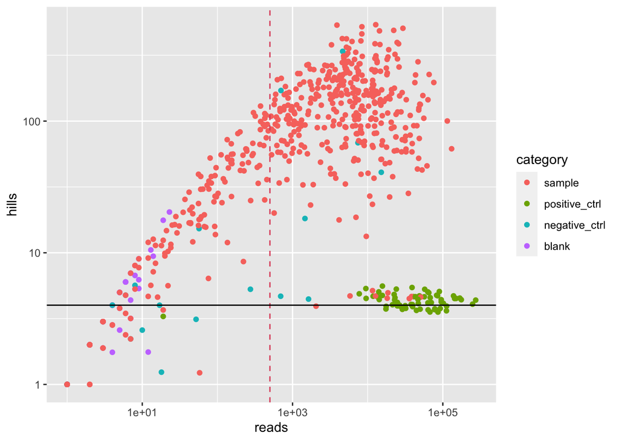

```r
chlo02_raw.clean %>% plot_reads_x_motus(q = 1, threshold = 0.00, limit = 500) +
  geom_hline(yintercept = 4)
```

## 2.7 Filters out sequences that are not considered as true sequences by obiclean

```r
# Sets the count of not true sequences to 0.
chlo02_raw.center <- chlo02_raw.clean
chlo02_raw.center@reads[chlo02_raw.clean$obiclean_status != "h"] <- 0

# Removes MOTUs occurring in any samples
chlo02_raw.center <- chlo02_raw.center[, colSums(chlo02_raw.center@reads) > 0]

# Removes empty samples
chlo02_raw.center <- chlo02_raw.center[which(rowSums(chlo02_raw.center@reads) > 0), ]

# Erases the original large data set
rm(chlo02_raw.clean)
```

## 2.8 Adds a taxo_group column to the MOTU description with three categories :

- Chlorophyceae
- Others
- Not annoted

The `Not annoted` category corresponds to MOTU without similarity with the reference database. The ’Others" category corresponds to non *Chlorophyceae* MOTUs.

```r
motus_cat <- rep("Others", ncol(chlo02_raw.center))

chlorophita.taxid <- ecofind(ncbi, "^chlorophyceae$")
is_chlorophyceae <- is.subcladeof(ncbi, chlo02_raw.center@motus$taxid, chlorophita.taxid)
motus_cat[is_chlorophyceae] <- "Chlorophyceae"
motus_cat[chlo02_raw.center@motus$taxid == 1] <- "Not annoted"

chlo02_raw.center@motus$taxo_group <- factor(motus_cat,
  levels = c("Chlorophyceae", "Others", "Not annoted")
)
```

Plot for each PCR then hill’s number diversity for $q=1$ as a function of read numbers associated to that PCR.

The theoritical Hill’s number for positive controle is $^1D=4$.

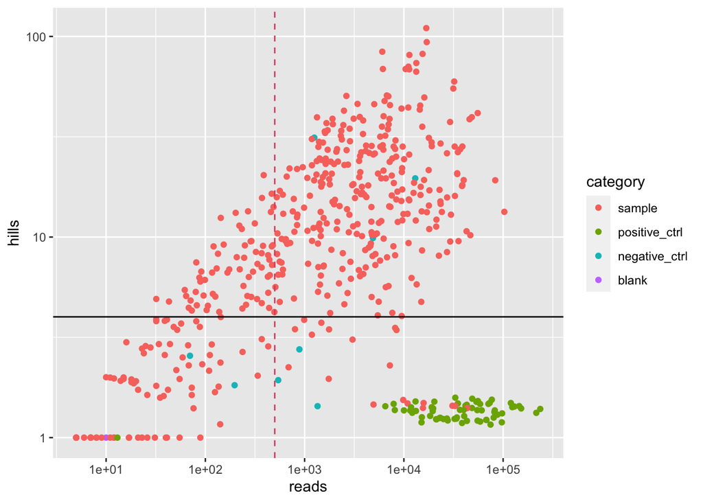

```r
chlo02_raw.center %>% plot_reads_x_motus(q = 1, threshold = 0.00, limit = 500) +
  geom_hline(yintercept = 4)
```

## 2.9 Look for contaminents

### 2.9.1 Look for sequences present in positive controles and samples

The table resumes for each sequence occurring in positive controls how many times they occure in samples, positive controles and negative controles

```r
chlo02_in_positive_ctrls <- which(
  colSums(
    chlo02_raw.center@reads[
      chlo02_raw.center@samples$category == "positive_ctrl",
    ]
  ) > 0
)

data.frame(
  sample = colSums(chlo02_raw.center@reads[chlo02_raw.center@samples$category == "sample", chlo02_in_positive_ctrls]),

  positive = colSums(chlo02_raw.center@reads[
    chlo02_raw.center@samples$category == "positive_ctrl",
    chlo02_in_positive_ctrls
  ]),

  negative = colSums(chlo02_raw.center@reads[
    chlo02_raw.center@samples$category == "negative_ctrl",
    chlo02_in_positive_ctrls
  ])
)
```

|  | sample | positive | negative |
| --- | --- | --- | --- |
| HISEQ:290:CCU08ANXX:1:1101:6513:2094_CONS_SUB_SUB_CMP | 150096 | 3194416 | 0 |
| HISEQ:290:CCU08ANXX:1:1109:8863:35581_CONS_SUB_SUB_CMP | 0 | 20 | 0 |
| HISEQ:290:CCU08ANXX:1:1101:11830:15642_CONS_SUB_SUB_CMP | 284 | 4404 | 0 |
| HISEQ:290:CCU08ANXX:1:1101:3301:41043_CONS_SUB_SUB_CMP | 9 | 324 | 0 |
| HISEQ:290:CCU08ANXX:1:1208:15873:68216_CONS_SUB_SUB | 0 | 6 | 0 |
| HISEQ:290:CCU08ANXX:1:1101:20062:4228_CONS_SUB_SUB_CMP | 634 | 13535 | 0 |
| HISEQ:290:CCU08ANXX:1:1101:12246:43812_CONS_SUB_SUB_CMP | 150 | 4808 | 0 |
| HISEQ:290:CCU08ANXX:1:1111:17518:33264_CONS_SUB_SUB_CMP | 0 | 212 | 0 |
| HISEQ:290:CCU08ANXX:1:1103:21191:4284_CONS_SUB_SUB_CMP | 0 | 7 | 0 |
| HISEQ:290:CCU08ANXX:1:1102:17883:26392_CONS_SUB_SUB | 294 | 4517 | 0 |

[output cut: 19 more lines]

#### 2.9.1.1 Examines the distribution of MOTU HISEQ:290:CCU08ANXX:1:1101:6513:2094_CONS_SUB_SUB_CMP

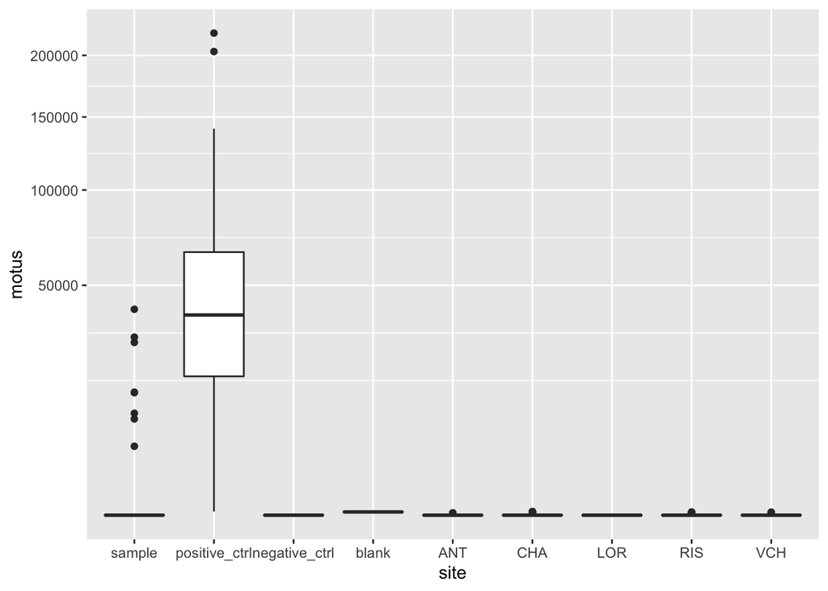

```r
cont <- "HISEQ:290:CCU08ANXX:1:1101:6513:2094_CONS_SUB_SUB_CMP"
data.frame(
  motus = chlo02_raw.center@reads[, cont],
  site = chlo02_raw.center@samples$site
) %>%
  ggplot(aes(x = site, y = motus)) +
  geom_boxplot() +
  scale_y_sqrt()
```

```r
tapply(chlo02_raw.center@reads[, cont], chlo02_raw.center@samples$site, max, na.rm = TRUE)
```

```
##        sample positive_ctrl negative_ctrl         blank           ANT
##         40117        219840             0            10             5
##           CHA           LOR           RIS           VCH
##            12             0             9             8
```

#### 2.9.1.2 Examines the distribution of MOTU HISEQ:290:CCU08ANXX:1:1101:20062:4228_CONS_SUB_SUB_CMP

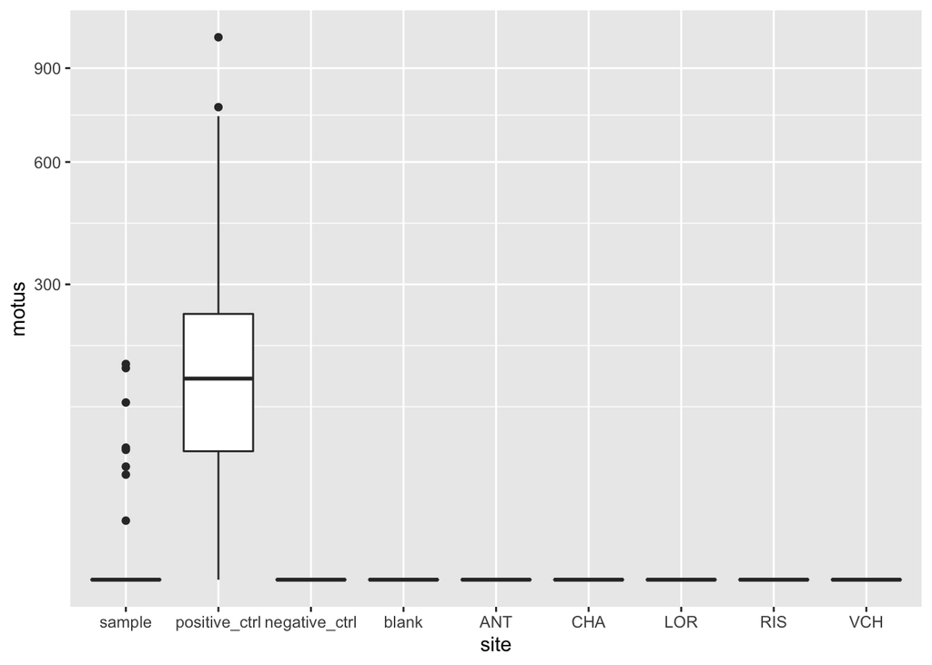

```r
cont <- "HISEQ:290:CCU08ANXX:1:1101:20062:4228_CONS_SUB_SUB_CMP"
data.frame(
  motus = chlo02_raw.center@reads[, cont],
  site = chlo02_raw.center@samples$site
) %>%
  ggplot(aes(x = site, y = motus)) +
  geom_boxplot() +
  scale_y_sqrt()
```

```r
tapply(chlo02_raw.center@reads[, cont], chlo02_raw.center@samples$site, max, na.rm = TRUE)
```

```
##        sample positive_ctrl negative_ctrl         blank           ANT
##           160          1012             0             0             0
##           CHA           LOR           RIS           VCH
##             0             0             0             0
```

### 2.9.2 Look for sequences present in negative PCR controles and samples

```r
chlo02_in_negative_ctrls <- which(
  colSums(
    chlo02_raw.center@reads[
      chlo02_raw.center@samples$category == "negative_ctrl",
    ]
  ) > 0
)

maxneg <- aggregate(chlo02_raw.center[, chlo02_in_negative_ctrls],
  MARGIN = 1,
  by = list(category = chlo02_raw.center@samples$category),
  FUN = max
)
neg_ctrls <- data.frame(
  sample = colSums(chlo02_raw.center@reads[
    chlo02_raw.center@samples$category == "sample",
    chlo02_in_negative_ctrls
  ]),
  positive = colSums(chlo02_raw.center@reads[
    chlo02_raw.center@samples$category == "positive_ctrl",
    chlo02_in_negative_ctrls
  ]),
  negative = colSums(chlo02_raw.center@reads[
    chlo02_raw.center@samples$category == "negative_ctrl",
    chlo02_in_negative_ctrls
  ]),
  max_in = levels(maxneg@samples$category)[apply(maxneg@reads, 2, which.max)],
  idx = chlo02_in_negative_ctrls
)

neg_ctrls
```

|  | sample | positive | negative | max_in | idx |
| --- | --- | --- | --- | --- | --- |
| HISEQ:290:CCU08ANXX:1:1101:14834:62515_CONS_SUB_SUB | 0 | 0 | 1089 | negative_ctrl | 61 |
| HISEQ:290:CCU08ANXX:1:1102:20242:9717_CONS_SUB_SUB_CMP | 1684 | 0 | 213 | sample | 196 |
| HISEQ:290:CCU08ANXX:1:1309:5398:70754_CONS_SUB_SUB_CMP | 0 | 0 | 26 | negative_ctrl | 529 |
| HISEQ:290:CCU08ANXX:1:1105:11333:92127_CONS_SUB_SUB | 0 | 0 | 106 | negative_ctrl | 848 |
| HISEQ:290:CCU08ANXX:1:1103:1779:50477_CONS_SUB_SUB | 0 | 0 | 153 | negative_ctrl | 849 |
| HISEQ:290:CCU08ANXX:1:1212:3888:66624_CONS_SUB_SUB | 95 | 0 | 17 | sample | 901 |
| HISEQ:290:CCU08ANXX:1:1201:7662:99106_CONS_SUB_SUB | 0 | 0 | 23 | negative_ctrl | 971 |
| HISEQ:290:CCU08ANXX:1:1113:5915:42322_CONS_SUB_SUB_CMP | 0 | 0 | 58 | negative_ctrl | 1071 |
| HISEQ:290:CCU08ANXX:1:1112:16496:25581_CONS_SUB_SUB | 0 | 0 | 627 | negative_ctrl | 1102 |
| HISEQ:290:CCU08ANXX:1:1108:18821:2708_CONS_SUB_SUB_CMP | 395 | 0 | 42 | sample | 1209 |

[output cut: 103 more lines]

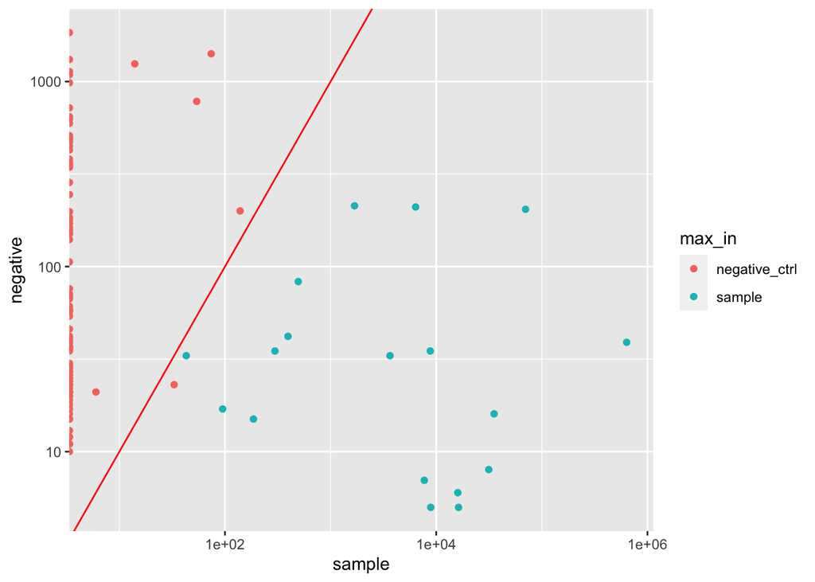

```r
neg_ctrls %>% ggplot(aes(x = sample, y = negative, col = max_in)) +
  geom_point() +
  scale_x_log10() +
  scale_y_log10() +
  geom_abline(slope = 1, intercept = 0, col = "red")
```

#### 2.9.2.1 Remove a potentiol contaminent from negative controle

Each MOTU more abundant in the negative controls than in the samples is removed.

```r
chlo02_raw.center <- chlo02_raw.center[, -(neg_ctrls[neg_ctrls$max_in == "negative_ctrl", "idx"])]
```

Clean the dataset by removing every empty PCR

```r
chlo02_raw.center <- chlo02_raw.center[which(rowSums(chlo02_raw.center@reads) > 0), ]
dim(chlo02_raw.center)
```

```
## [1]  529 8608
```

## 2.10 Number of replicate per PCR category

Counts how many PCR replicates are conserved at that level of the analysis.

```r
n_pcr <- table(chlo02_raw.center@samples$sampleid)[as.character(chlo02_raw.center@samples$sampleid)]
table(n_pcr, chlo02_raw.center@samples$site)
```

```
##
## n_pcr sample positive_ctrl negative_ctrl blank ANT CHA LOR RIS VCH
##     1      0             0             2     1   1   0   1   0   1
##     2      9             0             2     0  24  14  22  27   8
##     3     35            64             0     0  69  84  66  55  44
```

## 2.11 Filters out PCR replicats with too few reads

Plots for every PCR its diversity as a function of read counts

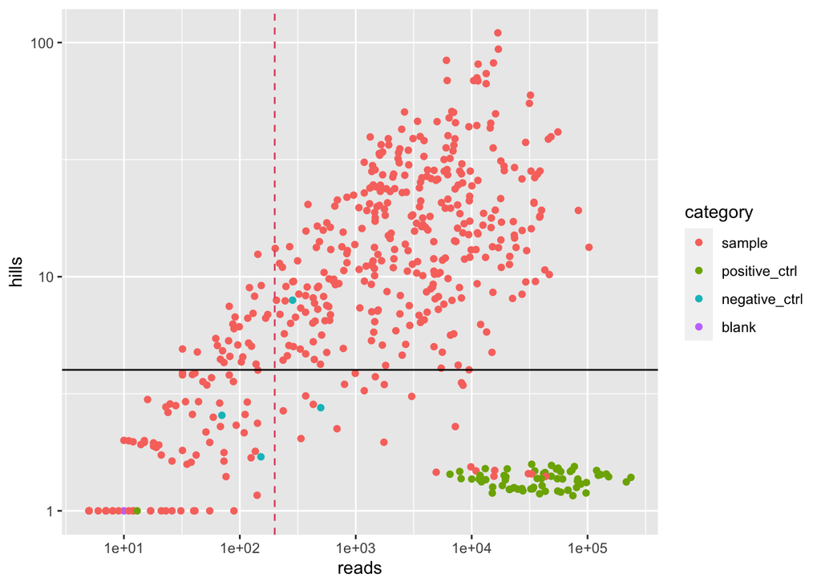

```r
chlo02_raw.center %>% plot_reads_x_motus(q = 1, threshold = 0.00, limit = 200) + geom_hline(yintercept = 4)
```

Keeps only PCRs with more than 200 reads. MOTUs having no more representants are removed

```r
chlo02_raw.center <- chlo02_raw.center[rowSums(chlo02_raw.center@reads) >= 200, ]
chlo02_raw.center <- chlo02_raw.center[, colSums(chlo02_raw.center@reads) > 0]
```

## 2.12 Checks similarity between PCR replicates

```r
chlo02.keep1 <- tag_bad_pcr(chlo02_raw.center@samples$sampleid,
  counts = chlo02_raw.center@reads
)
```

[figure not shown]

The dissimilarity distribution of PCR replicates is bimodal. Low dissimilarity replicates correspond to positive controls, the second mode corresponds to samples.

```r
chlo02_by_taxo_group <- aggregate(chlo02_raw.center, MARGIN = 2, by = list(chlo02_raw.center@motus$taxo_group), FUN = sum)
chlo02_raw.center@samples$chlorophyceae_part <- chlo02_by_taxo_group@reads[, 1] / rowSums(chlo02_by_taxo_group@reads)
chlo02_raw.center@samples$dist_barycenter <- chlo02.keep1$distance
```

The lower replicability of the samples is be explained by a very low amount of DNA as shown in the following plot.

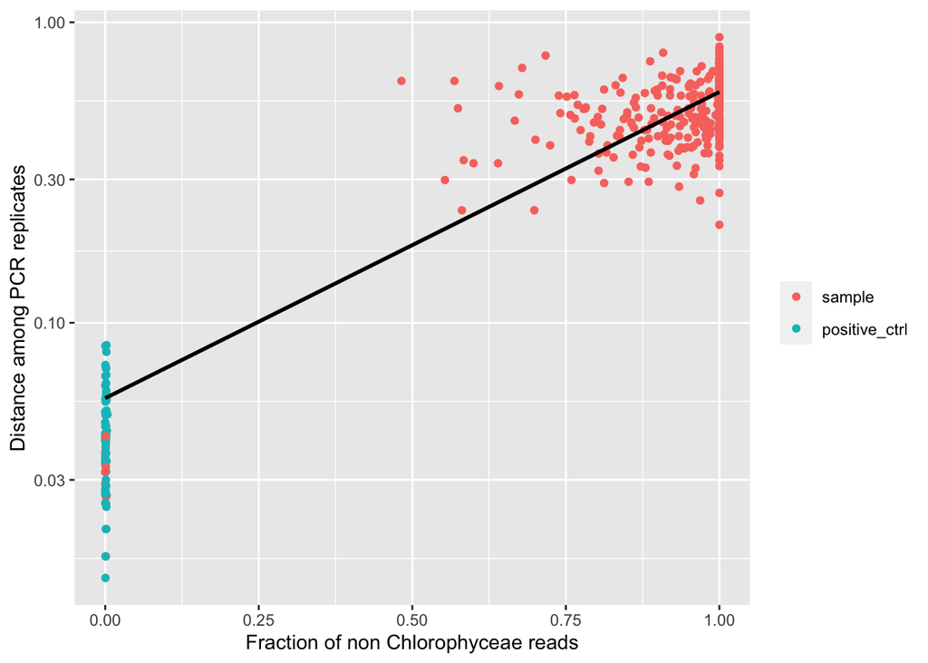

```r
data <- data.frame(
  x = chlo02.keep1$distance,
  y = 1 - chlo02_by_taxo_group@reads[, 1] / rowSums(chlo02_by_taxo_group@reads),
  col = chlo02_raw.center@samples$category,
  pch = as.character(table(chlo02_raw.center@samples$sampleid)[as.character(chlo02_raw.center@samples$sampleid)]),
  ok = table(chlo02_raw.center@samples$sampleid)[as.character(chlo02_raw.center@samples$sampleid)] > 1 &
    chlo02_raw.center@samples$category == "sample"
)

ggplot(data[table(chlo02_raw.center@samples$sampleid)[as.character(chlo02_raw.center@samples$sampleid)] > 1, ], aes(x = y, y = x, col = col)) +
  geom_point() +
  scale_y_log10() +
  ylab("Distance among PCR replicates") +
  xlab("Fraction of non Chlorophyceae reads") +
  stat_smooth(data = data[data$ok, ], col = "black", method = "lm", se = FALSE) +
  theme(legend.title = element_blank())
```

Estimates the linear model for the sample PCRs.

```r
ok <- table(chlo02_raw.center@samples$sampleid)[as.character(chlo02_raw.center@samples$sampleid)] > 1 &
  chlo02_raw.center@samples$category == "sample" & data$x > 0 & data$y > 0

l <- lm(log(data$x[ok]) ~ data$y[ok], na.action = na.omit)
summary(l)
```

```
##
## Call:
## lm(formula = log(data$x[ok]) ~ data$y[ok], na.action = na.omit)
##
## Residuals:
##      Min       1Q   Median       3Q      Max
## -1.40960 -0.18667  0.01735  0.17777  1.20383
##
## Coefficients:
##             Estimate Std. Error t value Pr(>|t|)
## (Intercept)  -2.6857     0.1034  -25.97   <2e-16 ***
## data$y[ok]    2.1402     0.1109   19.30   <2e-16 ***
## ---
## Signif. codes:  0 '***' 0.001 '**' 0.01 '*' 0.05 '.' 0.1 ' ' 1
##
## Residual standard error: 0.2995 on 318 degrees of freedom
## Multiple R-squared:  0.5396, Adjusted R-squared:  0.5381
## F-statistic: 372.6 on 1 and 318 DF,  p-value: < 2.2e-16
```

```r
cor(log(data$x[ok]), data$y[ok], use = "complete.obs")^2
```

```
## [1] 0.5395574
```

More Chlorophyceae reads in the PCR closer are the replicates. The Chlorophyceae amount of DNA seems to be the limitant factor.

## 2.13 Preprares the final data set for ecological analysis

We now just focus on the target group and remove every control PCRs

```r
chlo02.chlorophyceae <- chlo02_raw.center[, chlo02_raw.center@motus$taxo_group == "Chlorophyceae"]
chlo02.chlorophyceae <- chlo02.chlorophyceae[which(rowSums(chlo02.chlorophyceae@reads) > 0), ]
chlo02.chlorophyceae <- chlo02.chlorophyceae[which(chlo02.chlorophyceae@samples$category == "sample"), ]
chlo02.chlorophyceae <- chlo02.chlorophyceae[, which(colSums(chlo02.chlorophyceae@reads) > 0)]
```

and we merge the sites metadata

```r
orchamp_env <- read.csv("orchamp_env.csv", header = TRUE)
sample_descr <- read.csv2("labels_metabar_trie.csv", header = TRUE)
code_plot <- paste(sample_descr$Site_short, sample_descr$Altitude, sample_descr$Horizon, sep = "_")
sample_descr$Code_plot <- code_plot
left_join(sample_descr, orchamp_env) %>% right_join(chlo02.chlorophyceae@samples, by = c(EXTRACTION.CODE = "sampleid")) -> samples
rownames(samples) <- as.character(samples$sample)
chlo02.chlorophyceae@samples <- samples

chlo02.chlorophyceae@motus$class <- taxonatrank(ncbi, chlo02.chlorophyceae@motus$taxid, "class", name = TRUE)
```

```r
table(table(chlo02.chlorophyceae@samples$EXTRACTION.CODE)[as.character(chlo02.chlorophyceae@samples$EXTRACTION.CODE)], chlo02.chlorophyceae@samples$Site_short)
```

```
##
##     ANT CHA LOR RIS VCH
##   1  11   2   9   7  10
##   2   8  16   2  22  10
##   3   6  45   6  15  18
```

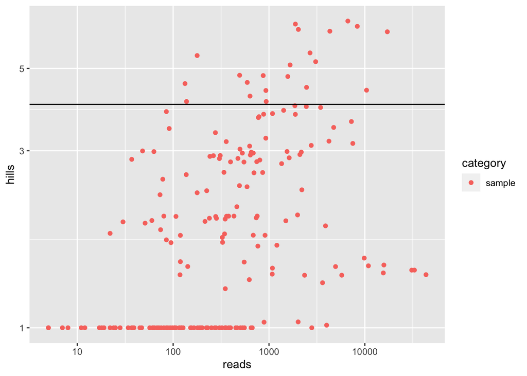

```r
chlo02.chlorophyceae %>% plot_reads_x_motus(q = 1, threshold = 0.00) + geom_hline(yintercept = 4)
```

# 3 Saves the cleaned data set

```r
dir.create("cleaned_datasets", showWarnings = FALSE)
write.csv2(chlo02.chlorophyceae@reads, file = "cleaned_datasets/Chlo02.cleaned.reads.csv")
write.csv2(chlo02.chlorophyceae@motus, file = "cleaned_datasets/Chlo02.cleaned.motus.csv")
write.csv2(chlo02.chlorophyceae@samples, file = "cleaned_datasets/Chlo02.cleaned.samples.csv")
```